# Plotting Diagnostics for LM and GLM with ggplot2 and ggfortify

This document explains plotting diagnostics for LM and GLM using `ggplot2` and `ggfortify`.

# Installation

First, install `ggfortify` from [github](https://github.com/sinhrks/ggfortify).

```r
library(devtools)
install_github('sinhrks/ggfortify')
```

# Plotting Diagnostics for Linear Models

`ggfortify` let `ggplot2` know how to interpret `lm` objects. After loading `ggfortify`, you can use `ggplot2::autoplot` function for `lm` objects.

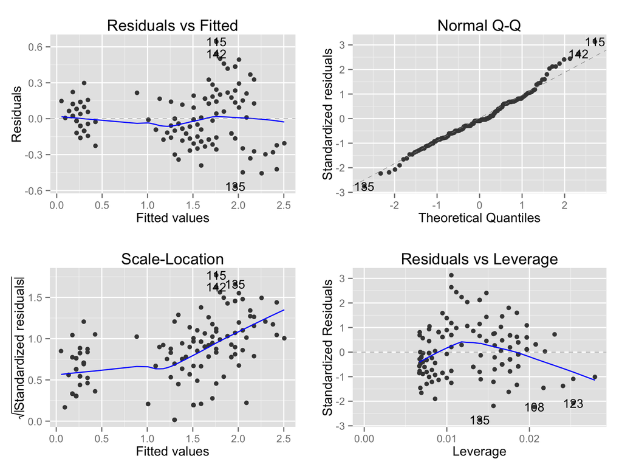

```r
library(ggplot2)
library(ggfortify)
autoplot(lm(Petal.Width ~ Petal.Length, data = iris))
```

You can select desired plot by `which` option as the same manner as standard `plot`. Following shows the comparison between `ggfortify` and default `plot` output.

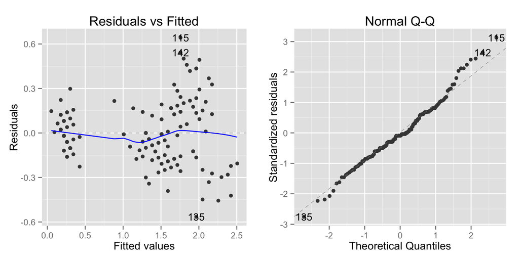

```r
par(mfrow = c(1, 2))
m <- lm(Petal.Width ~ Petal.Length, data = iris)

autoplot(m, which = 1:2, ncol = 2)
```

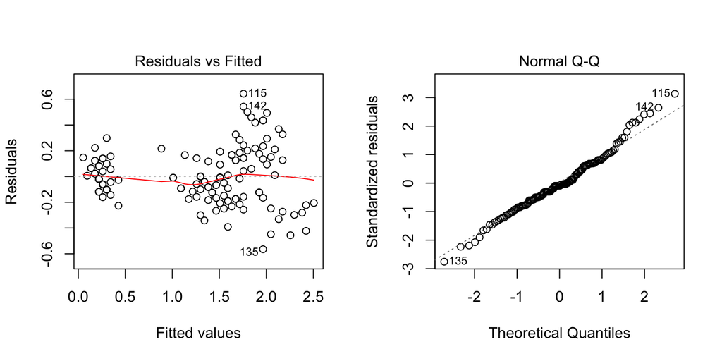

```r
# Standard plot (for comparison)
plot(m, which = 1:2)
```

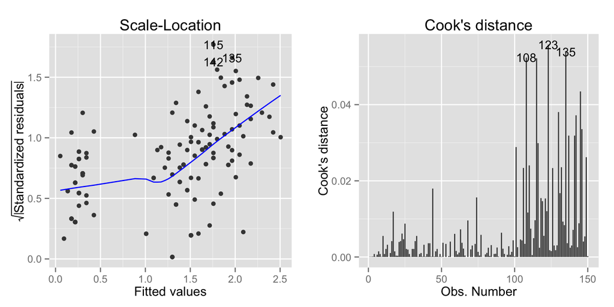

```r
autoplot(m, which = 3:4, ncol = 2)
```

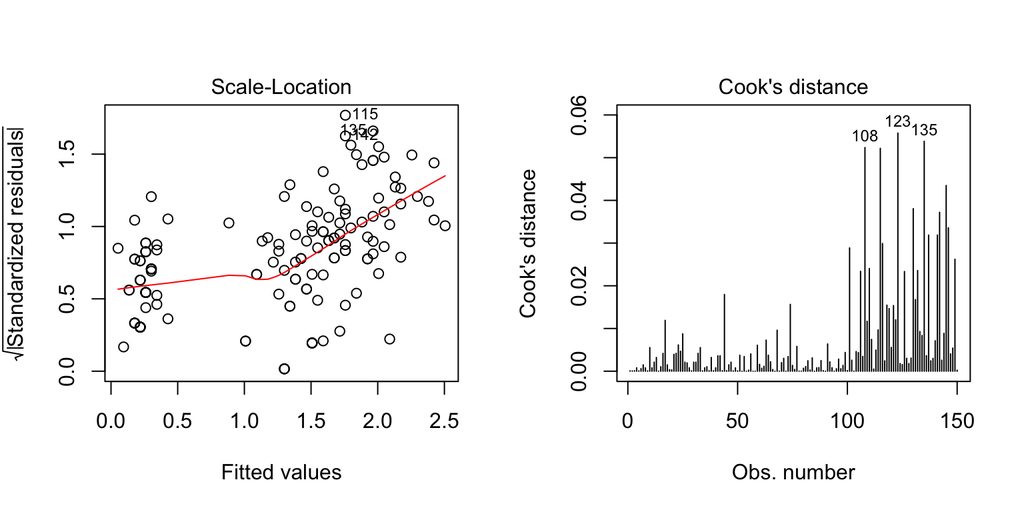

```r
# Standard plot (for comparison)
plot(m, which = 3:4)
```

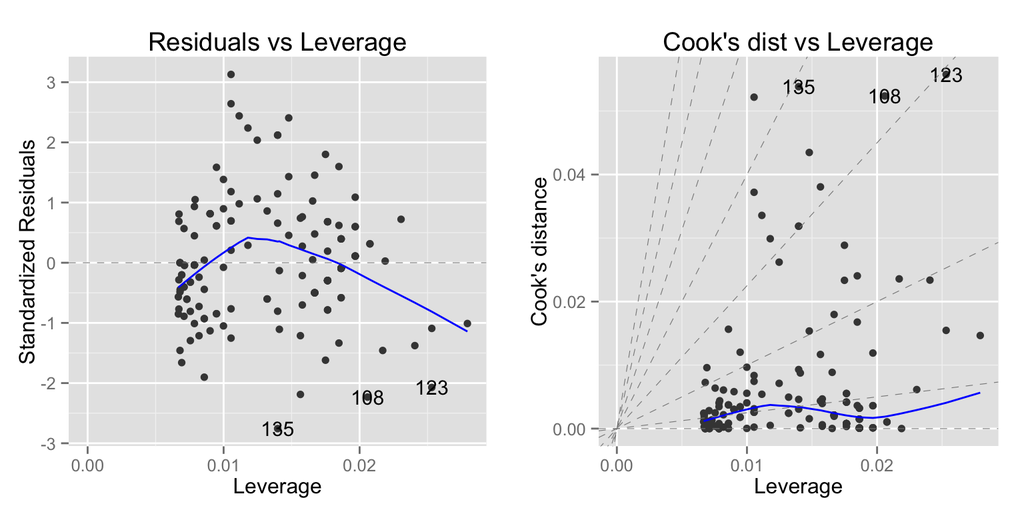

```r
autoplot(m, which = 5:6, ncol = 2)
```

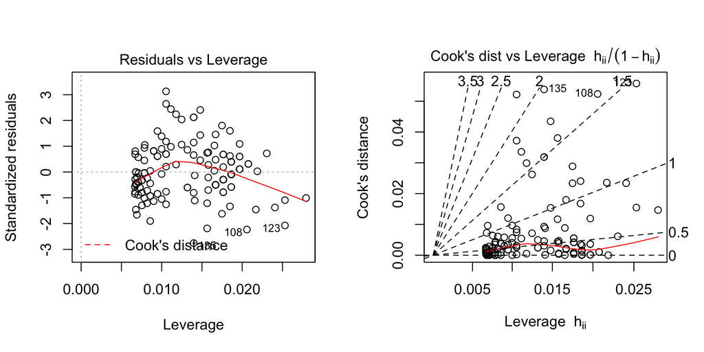

```r
# Standard plot (for comparison)
plot(m, which = 5:6)
```

# Plotting Diagnostics for Generalized Linear Models

It also suppotgs `glm` instance.

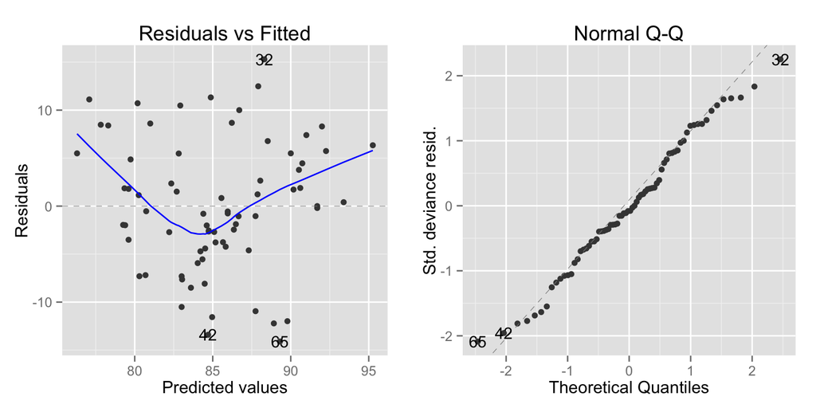

```r
par(mfrow = c(1, 2))
utils::data(anorexia, package = "MASS")
m <- glm(Postwt ~ Prewt + Treat + offset(Prewt),
         family = gaussian, data = anorexia)

autoplot(m, which = 1:2, ncol = 2)
```

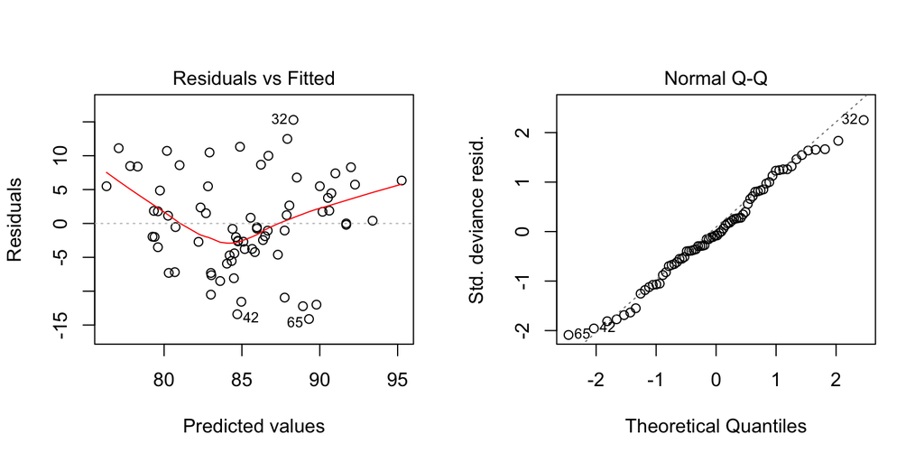

```r
# Standard plot (for comparison)
plot(m, which = 1:2)
```

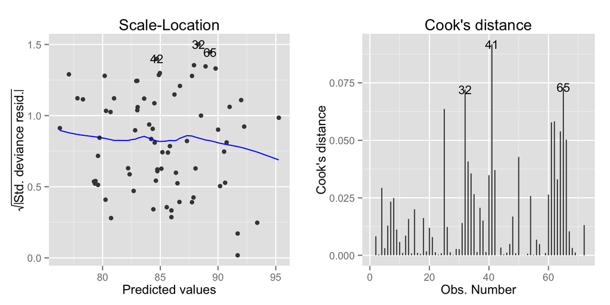

```r
autoplot(m, which = 3:4, ncol = 2)
```

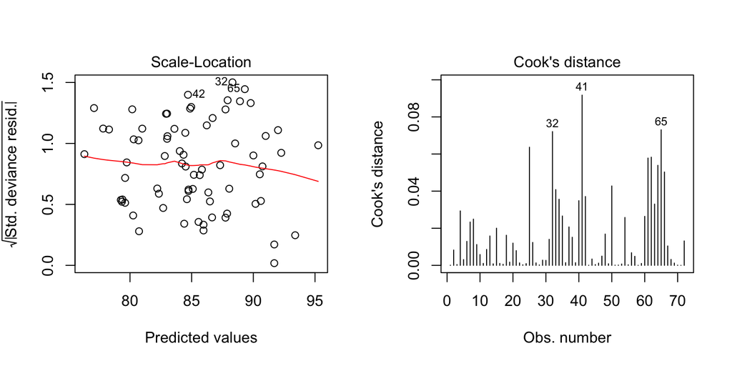

```r
# Standard plot (for comparison)
plot(m, which = 3:4)
```

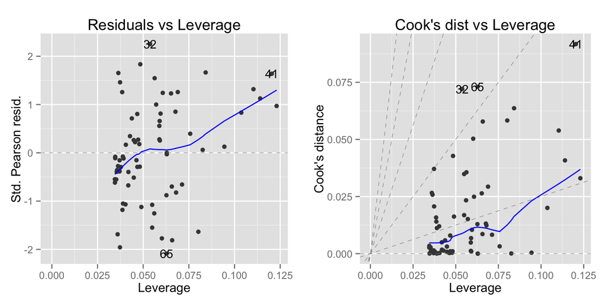

```r
autoplot(m, which = 5:6, ncol = 2)
```

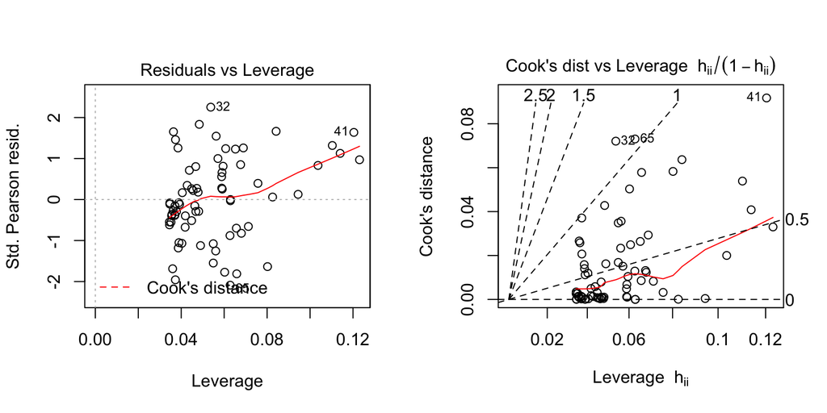

```r
# Standard plot
plot(m, which = 5:6)
```

# Specifing Plotting Options

Some properties can be changed by passing corresponding keywords. For example, `colour` keyword is for data points, `smooth.colour` is for smoothing lines and `ad.colour` is for additional auxiliary lies. Also, `ncol` and `nrow` control facet layout. Use `help(autoplot.lm)` (or `help(autoplot.*)` for any other objects) to check available options.

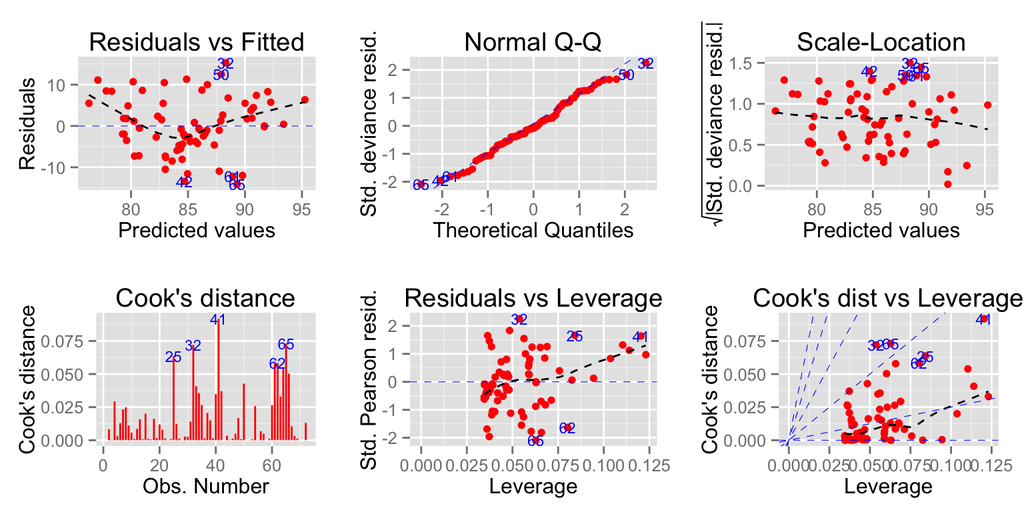

```r
autoplot(m, which = 1:6, colour = 'red',
         smooth.colour = 'black', smooth.linetype = 'dashed',
         ad.colour = 'blue',
         label.size = 3, label.n = 5, label.colour = 'blue',
         ncol = 3)
```

# Resources related to ggfortify

- [Plotting Diagnostics for LM and GLM with ggplot2 and ggfortify](http://rpubs.com/sinhrks/plot_lm)
- [Plotting Time Series with ggplot2 and ggfortify](http://rpubs.com/sinhrks/plot_ts)
- [Plotting Time Series Statistics with ggplot2 and ggfortify](http://rpubs.com/sinhrks/plot_tsstats)
- [Plotting PCA/clustering results using ggplot2 and ggfortify](http://rpubs.com/sinhrks/plot_pca)
- [Plotting Survival Curves using ggplot2 and ggfortify](http://rpubs.com/sinhrks/plot_surv)
- [Plotting Probability Distributions with ggplot2 and ggfortify](http://rpubs.com/sinhrks/plot_dist)